# Tugas-Model ARIMA-Praktikum MPDW

FADILLAH HANDAYANI

2026-10-04

```r
# Download Packages
library(readxl)
library(tseries)
library(MASS)
library(forecast)
library(TSA)
library(lmtest)
```

# Data

## Impor dan Penyiapan Data

File Excel data BBCA 2026 menyimpan setiap baris sebagai satu teks berbentuk `tanggal,Close` dalam **satu kolom**, sehingga perlu dipisahkan terlebih dahulu. Hari bursa yang tidak memiliki harga penutupan (`NA`) dicek sebelum dibuang.

```r
raw <- read_excel("C:\\Users\\ridho\\OneDrive\\Documents\\DATA BBCA 2026_MPDW.xlsx")

if (ncol(raw) == 1) {
  # tanggal dan Close tergabung dalam satu kolom teks "tanggal,Close"
  bagian <- strsplit(as.character(raw[[1]]), ",")
  bbca <- data.frame(Tanggal = as.Date(sapply(bagian, `[`, 1)),
                     Close   = suppressWarnings(as.numeric(sapply(bagian, `[`, 2))))
} else {
  bbca <- data.frame(Tanggal = as.Date(raw[[1]]),
                     Close   = suppressWarnings(as.numeric(raw[[2]])))
}

colSums(is.na(bbca))
```

```
## Tanggal   Close
##       0       4
```

```r
bbca[is.na(bbca$Close), ]
```

```
##         Tanggal Close
## 1524 2026-05-01    NA
## 1545 2026-06-01    NA
## 1556 2026-06-16    NA
## 1600 2026-08-17    NA
```

Terdapat 4 data hilang, yaitu tanggal 01 Mei 2026, 01 Juni 2026, 16 Juni 2026, dan 17 Agustus 2026. Keempatnya jatuh pada hari libur nasional (1 Mei, 1 Juni, 16 Juni, dan 17 Agustus) ketika bursa tutup, sehingga bukan kesalahan pencatatan dan baris tersebut aman dibuang (bukan diimputasi).

```r
bbca <- bbca[!is.na(bbca$Close), ]
str(bbca)
```

```
## 'data.frame':    1600 obs. of  2 variables:
##  $ Tanggal: Date, format: "2020-01-02" "2020-01-03" ...
##  $ Close  : num  6690 6800 6735 6740 6680 ...
```

```r
head(bbca)
```

```
##      Tanggal Close
## 1 2020-01-02  6690
## 2 2020-01-03  6800
## 3 2020-01-06  6735
## 4 2020-01-07  6740
## 5 2020-01-08  6680
## 6 2020-01-09  6740
```

```r
tail(bbca)
```

```
##         Tanggal Close
## 1598 2026-08-13  6375
## 1599 2026-08-14  6350
## 1601 2026-08-18  6300
## 1602 2026-08-19  6300
## 1603 2026-08-20  6400
## 1604 2026-08-21  6450
```

Setelah baris `NA` dibuang, data berisi 1600 pengamatan harian dari 02 Januari 2020 sampai 21 Agustus 2026.

# Pembagian Data Latih dan Data Uji

Data dibagi dengan proporsi 80 : 20 secara berurutan (data tidak boleh diacak karena berupa deret waktu). Dari 1600 pengamatan, 1280 pengamatan pertama menjadi data latih (02 Januari 2020 s.d. 23 April 2025) dan 320 pengamatan sisanya menjadi data uji (24 April 2025 s.d. 21 Agustus 2026). Proporsi dapat diubah dengan mengganti nilai `prop`.

```r
prop    <- 0.8
n       <- nrow(bbca)
n.train <- floor(prop * n)

train.ts <- ts(bbca$Close[1:n.train])
test.ts  <- ts(bbca$Close[(n.train + 1):n], start = n.train + 1)
h        <- length(test.ts)

c(n = n, n.train = n.train, n.test = h)
```

```
##       n n.train  n.test
##    1600    1280     320
```

## Plot Data Penuh

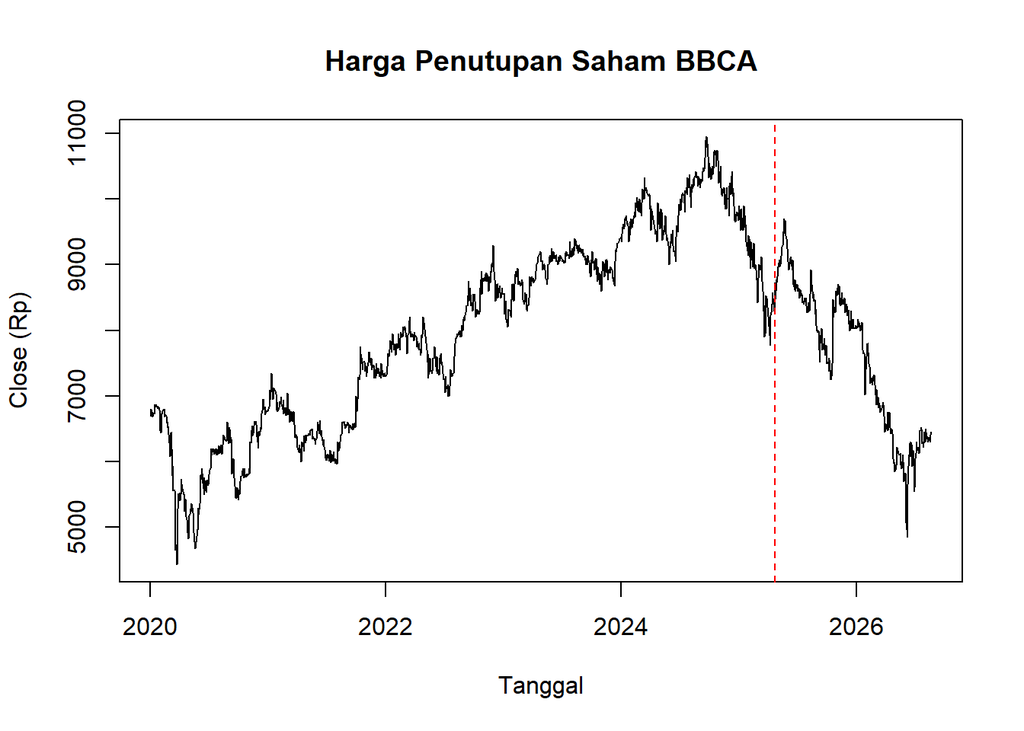

```r
plot(bbca$Tanggal, bbca$Close, type = "l", xlab = "Tanggal", ylab = "Close (Rp)",
     main = "Harga Penutupan Saham BBCA")
abline(v = bbca$Tanggal[n.train], col = "red", lty = 2)
```

Berdasarkan plot, harga BBCA cenderung naik dari sekitar Rp6.700 (awal 2020) hingga puncaknya sekitar Rp10.950 pada 2024, kemudian turun tajam sejak 2025 hingga sekitar Rp4.850 pada 2026. Data tidak berfluktuasi di sekitar satu nilai tengah tertentu, sehingga sejak awal terindikasi tidak stasioner dalam rataan. Penurunan tajam sebagian besar berada pada data uji (garis merah putus-putus menandai batas pembagian), sehingga data uji akan berperilaku sangat berbeda dari data latih. Hal ini penting untuk dipertimbangkan saat mengevaluasi hasil peramalan.

## Plot Data Latih

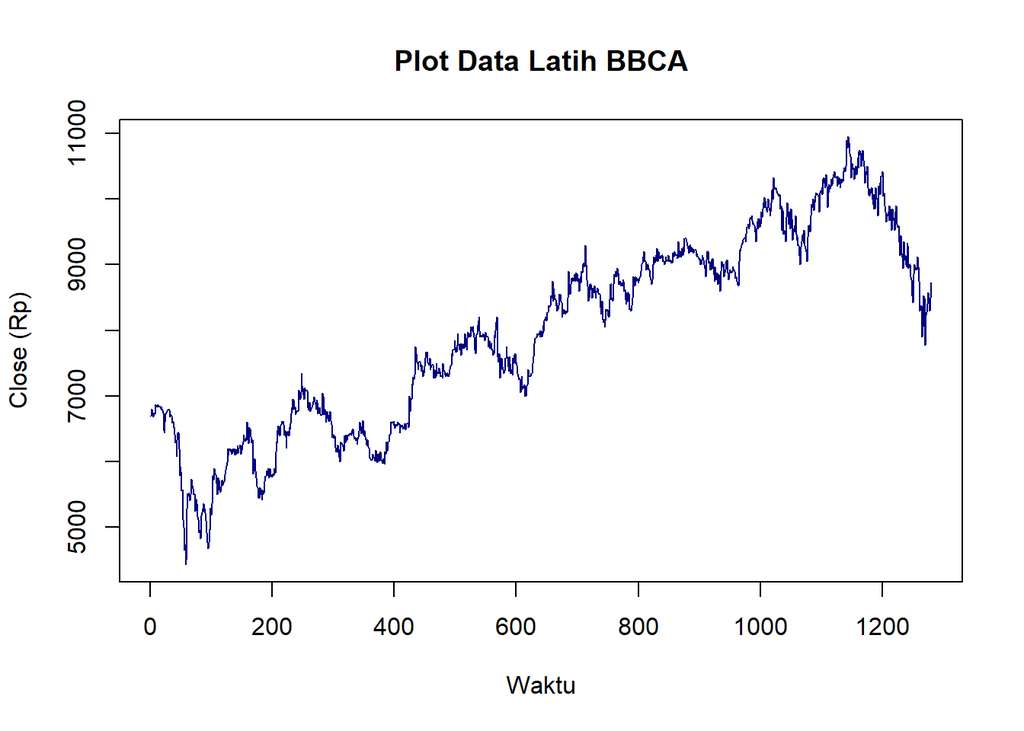

```r
plot.ts(train.ts, col = "navy", xlab = "Waktu", ylab = "Close (Rp)", main = "Plot Data Latih BBCA")
```

Data latih memperlihatkan tren naik jangka panjang dengan beberapa kali pergeseran level. Pola ini mengindikasikan data **tidak stasioner dalam rataan**.

## Plot Data Uji

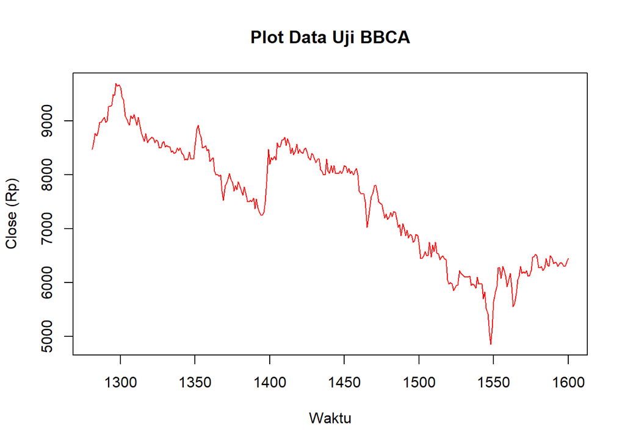

```r
plot.ts(test.ts, col = "red", xlab = "Waktu", ylab = "Close (Rp)", main = "Plot Data Uji BBCA")
```

# Uji Stasioneritas Data Latih

## Plot ACF

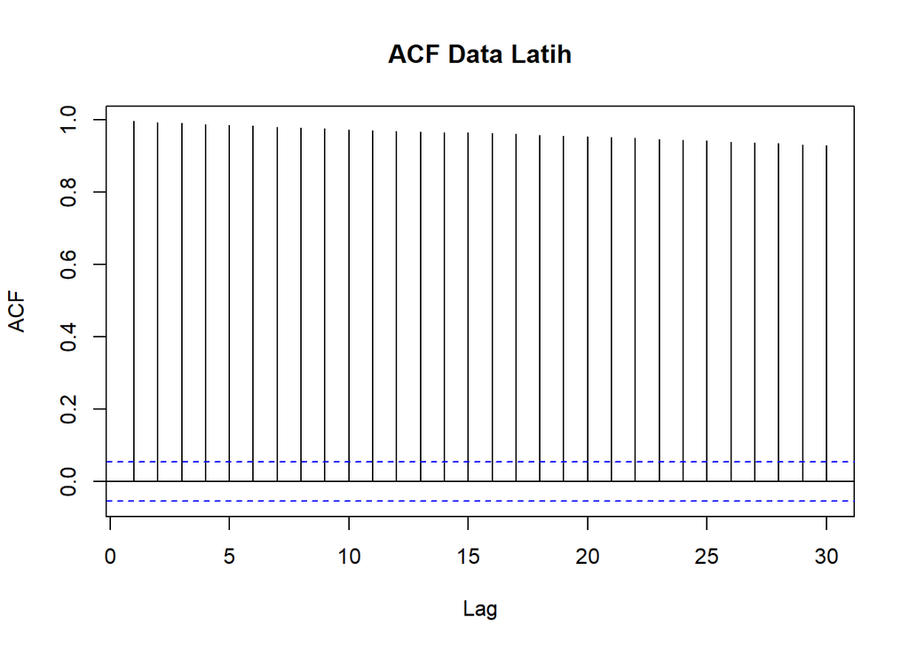

```r
acf(train.ts, lag.max = 30, main = "ACF Data Latih")
```

Plot ACF menurun sangat lambat (*tails off slowly*) dan nilainya masih sekitar 0,93 pada lag ke-30, jauh di atas batas signifikansi. Pola ini adalah ciri khas data yang **tidak stasioner dalam rataan**.

## Uji ADF

Hipotesis uji *Augmented Dickey-Fuller*:

$H_0$ : data tidak stasioner dalam rataan

$H_1$ : data stasioner dalam rataan

```r
tseries::adf.test(train.ts)
```

```
##
##  Augmented Dickey-Fuller Test
##
## data:  train.ts
## Dickey-Fuller = -2.7095, Lag order = 10, p-value = 0.278
## alternative hypothesis: stationary
```

Uji ADF menghasilkan *p-value* sebesar **0,278** yang lebih besar dari taraf nyata 5%, sehingga **tak tolak $H_0$**: data latih tidak stasioner dalam rataan. Hasil ini konsisten dengan plot deret waktu dan plot ACF, sehingga ketidakstasioneran dalam rataan harus ditangani dengan *differencing*.

## Plot Box-Cox (Kestasioneran dalam Ragam)

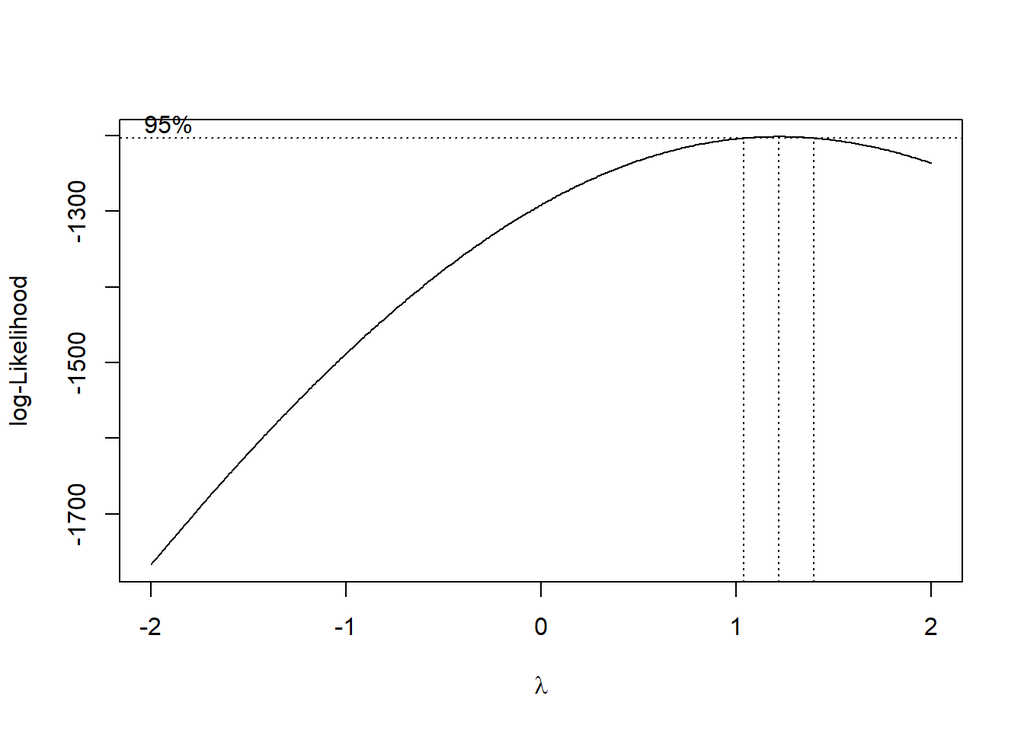

```r
index <- seq(1:n.train)

bc <- boxcox(train.ts ~ index, lambda = seq(-2, 2, by = 0.01))
```

```r
# nilai lambda optimum
lambda.opt <- bc$x[which.max(bc$y)]
lambda.opt
```

```
## [1] 1.22
```

```r
# selang kepercayaan 95% untuk lambda
ci.lambda <- bc$x[bc$y > max(bc$y) - 0.5 * qchisq(0.95, df = 1)]
c(Batas_Bawah = min(ci.lambda), Batas_Atas = max(ci.lambda))
```

```
## Batas_Bawah  Batas_Atas
##        1.05        1.39
```

Nilai $\lambda$ optimum sebesar **1,22** dengan selang kepercayaan 95% **[1,05 ; 1,39]**. Selang ini **tidak memuat angka 1** meskipun batas bawahnya hanya sedikit di atas 1, sehingga pada data asli ragam belum sepenuhnya stasioner. Perlu diingat bahwa pengecekan ini dilakukan pada data yang masih bertren. Karena itu pemeriksaan Box-Cox diulang pada data hasil *differencing* di bagian berikutnya sebelum memutuskan perlu tidaknya transformasi.

# Penanganan Ketidakstasioneran Data

## Differencing Pertama

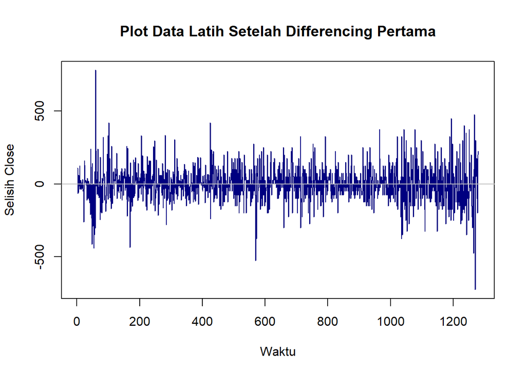

```r
train.diff <- diff(train.ts, differences = 1)
plot.ts(train.diff, col = "navy", xlab = "Waktu", ylab = "Selisih Close",
        main = "Plot Data Latih Setelah Differencing Pertama")
abline(h = 0, col = "gray")
```

Setelah *differencing* pertama, data bergerak di sekitar nilai tengah yang konstan (sekitar nol) dan tren sudah hilang, sehingga data terlihat **stasioner dalam rataan**. Lebar fluktuasi relatif seragam, meskipun terlihat beberapa periode dengan gejolak lebih besar (*volatility clustering*) yang akan dibahas pada analisis sisaan.

## Plot ACF

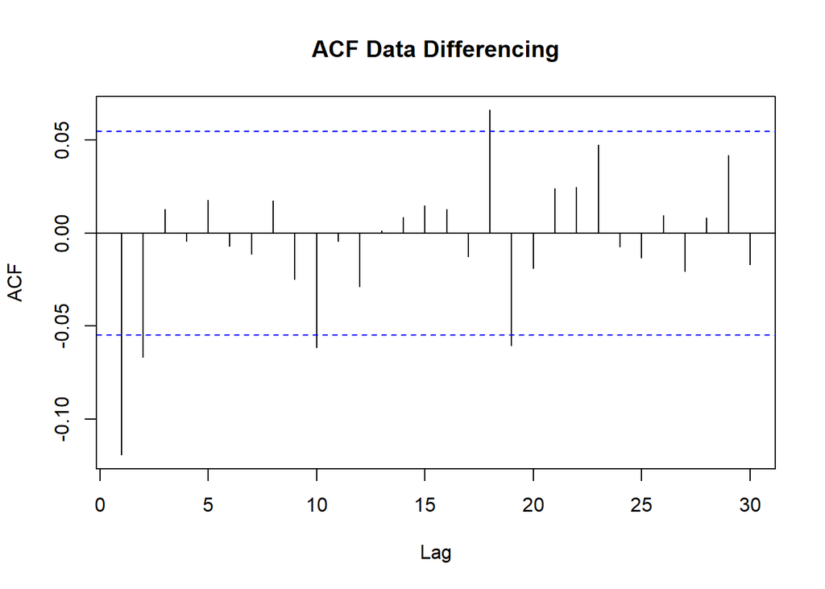

```r
acf(train.diff, lag.max = 30, main = "ACF Data Differencing")
```

Plot ACF data hasil *differencing* tidak lagi turun lambat. Nilainya langsung mengecil dan hampir seluruhnya berada di dalam batas signifikansi (±0,055), kecuali beberapa lag awal, sehingga data sudah stasioner dalam rataan.

## Uji ADF

```r
tseries::adf.test(train.diff)
```

```
##
##  Augmented Dickey-Fuller Test
##
## data:  train.diff
## Dickey-Fuller = -12.04, Lag order = 10, p-value = 0.01
## alternative hypothesis: stationary
```

Statistik uji ADF = -12,04 dengan *p-value* **≤ 0,01** (lebih kecil dari 5%), sehingga **tolak $H_0$**: data hasil *differencing* **stasioner dalam rataan**. Ini sesuai dengan plot dan ACF, sehingga ketidakstasioneran dalam rataan telah berhasil ditangani dengan **satu kali differencing (d = 1)**.

## Box-Cox pada Data Hasil Differencing

Data hasil *differencing* memiliki nilai negatif dan nol, sedangkan transformasi Box-Cox mensyaratkan data positif. Karena itu data digeser dengan konstanta $c = |\min| + 1$ = **726** sebelum dicek.

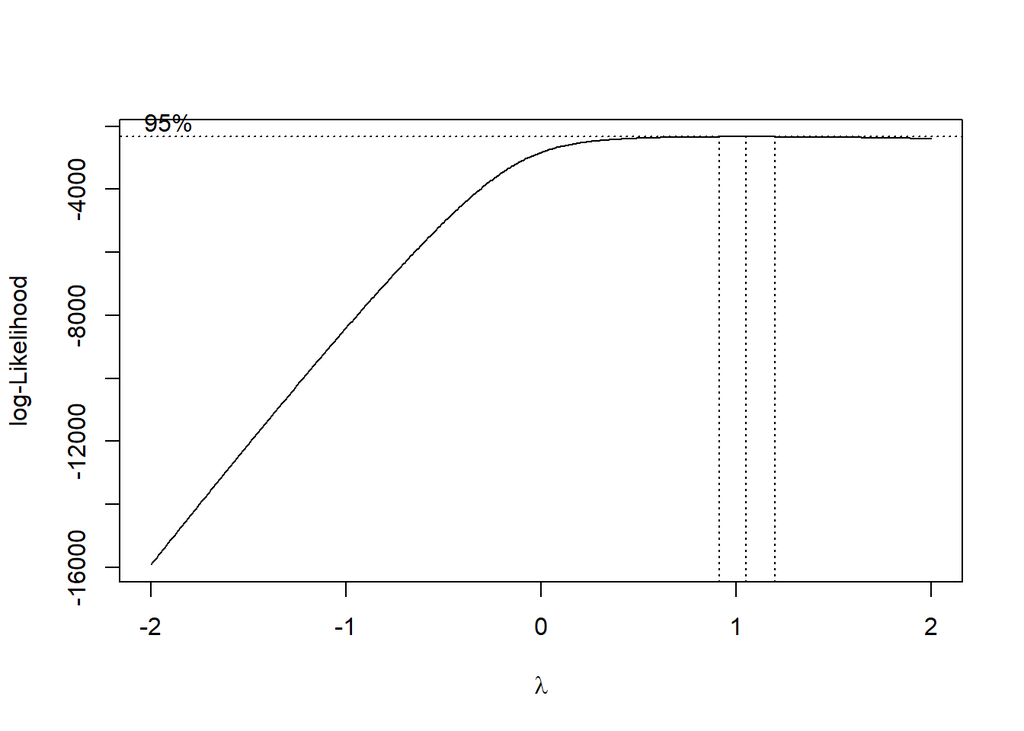

```r
index.diff <- seq(1:length(train.diff))

# geser data agar seluruh nilai positif
c.shift <- if (min(train.diff) <= 0) abs(min(train.diff)) + 1 else 0
train.diff.shift <- train.diff + c.shift

bc.diff <- boxcox(train.diff.shift ~ index.diff, lambda = seq(-2, 2, by = 0.01))
```

```r
lambda.diff <- bc.diff$x[which.max(bc.diff$y)]
lambda.diff
```

```
## [1] 1.05
```

```r
ci.diff <- bc.diff$x[bc.diff$y > max(bc.diff$y) - 0.5 * qchisq(0.95, df = 1)]
c(Batas_Bawah = min(ci.diff), Batas_Atas = max(ci.diff))
```

```
## Batas_Bawah  Batas_Atas
##        0.92        1.19
```

Pada data hasil *differencing*, nilai $\lambda$ optimum sebesar **1,05** dengan selang kepercayaan 95% **[0,92 ; 1,19]**. Selang tersebut **memuat angka 1**, sehingga data hasil *differencing* **stasioner dalam ragam** dan **tidak diperlukan transformasi**. Dengan demikian, penanganan yang dibutuhkan hanya *differencing* satu kali, sehingga model yang dibentuk berbentuk ARIMA(p,1,q).

# Identifikasi Model

## Plot ACF dan PACF

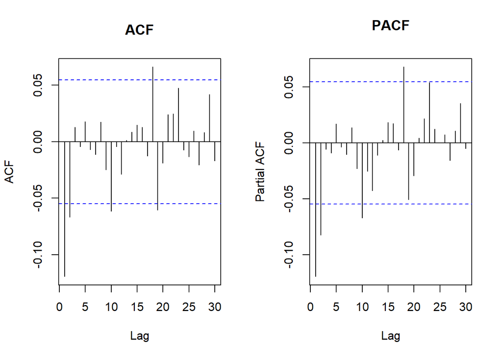

```r
par(mfrow = c(1, 2))
acf(train.diff,  lag.max = 30, main = "ACF")
pacf(train.diff, lag.max = 30, main = "PACF")
```

```r
par(mfrow = c(1, 1))
```

Dari plot ACF dan PACF data hasil *differencing*:

- **ACF**: lag 1 (-0,119) dan lag 2 (-0,067) melewati batas signifikansi (±0,055), kemudian *cuts off* setelah lag 2. Jika PACF dianggap *tails off*, model tentatifnya **ARIMA(0,1,2)**. Jika hanya lag 1 yang dianggap bermakna, modelnya **ARIMA(0,1,1)**.
- **PACF**: lag 1 (-0,119) dan lag 2 (-0,082) signifikan, kemudian *cuts off* setelah lag 2. Jika ACF dianggap *tails off*, model tentatifnya **ARIMA(2,1,0)**. Jika hanya lag 1 yang dianggap bermakna, modelnya **ARIMA(1,1,0)**.
- Jika ACF dan PACF sama-sama dianggap *tails off*, model tentatifnya **ARIMA(1,1,1)**.

Beberapa lag yang melewati batas pada lag yang lebih jauh (misalnya lag 10 dan 18) bersifat terisolasi dan masih wajar terjadi secara kebetulan, sebab dengan taraf 5% sekitar 1 dari 20 lag akan melewati batas.

## Plot EACF

```r
eacf(train.diff)
```

```
## AR/MA
##   0 1 2 3 4 5 6 7 8 9 10 11 12 13
## 0 x x o o o o o o o x o  o  o  o
## 1 x x o o o o o o o x o  o  o  o
## 2 x x o o o o o o o o o  o  o  o
## 3 x o x x o o o o o o o  o  o  o
## 4 x x o o o o o o o o o  o  o  o
## 5 x x x o o o o o o o o  o  o  o
## 6 x x o x o o o o o o o  o  o  o
## 7 x x x x x o o o o o o  o  o  o
```

**Model tentatif** gabungan ACF, PACF, dan EACF adalah: ARIMA(0,1,1), ARIMA(0,1,2), ARIMA(1,1,0), ARIMA(2,1,0), dan ARIMA(1,1,1).

# Pendugaan Parameter Model Tentatif

Pendugaan parameter dilakukan dengan `Arima()` metode *maximum likelihood* pada data hasil *differencing* (`order = c(p,0,q)`). Orde $d = 1$ sudah diterapkan secara manual pada `train.diff`. Signifikansi parameter dilihat dari `coeftest()` (taraf nyata 5%), dan kebaikan model dari nilai AIC.

## ARIMA(0,1,1)

```r
model.01 <- Arima(train.diff, order = c(0,0,1), method = "ML")
model.01
```

```
## Series: train.diff
## ARIMA(0,0,1) with non-zero mean
##
## Coefficients:
##           ma1    mean
##       -0.1401  1.5770
## s.e.   0.0297  2.9406
##
## sigma^2 = 14977:  log likelihood = -7962.18
## AIC=15930.36   AICc=15930.38   BIC=15945.82
```

```r
lmtest::coeftest(model.01)
```

```
##
## z test of coefficients:
##
##            Estimate Std. Error z value  Pr(>|z|)
## ma1       -0.140138   0.029664 -4.7241 2.311e-06 ***
## intercept  1.577012   2.940569  0.5363    0.5918
## ---
## Signif. codes:  0 '***' 0.001 '**' 0.01 '*' 0.05 '.' 0.1 ' ' 1
```

## ARIMA(0,1,2)

```r
model.02 <- Arima(train.diff, order = c(0,0,2), method = "ML")
model.02
```

```
## Series: train.diff
## ARIMA(0,0,2) with non-zero mean
##
## Coefficients:
##           ma1      ma2    mean
##       -0.1292  -0.0653  1.5678
## s.e.   0.0280   0.0280  2.7491
##
## sigma^2 = 14926:  log likelihood = -7959.47
## AIC=15926.95   AICc=15926.98   BIC=15947.56
```

```r
lmtest::coeftest(model.02)
```

```
##
## z test of coefficients:
##
##            Estimate Std. Error z value Pr(>|z|)
## ma1       -0.129196   0.028010 -4.6124 3.98e-06 ***
## ma2       -0.065328   0.028049 -2.3291  0.01986 *
## intercept  1.567766   2.749109  0.5703  0.56849
## ---
## Signif. codes:  0 '***' 0.001 '**' 0.01 '*' 0.05 '.' 0.1 ' ' 1
```

## ARIMA(1,1,0)

```r
model.10 <- Arima(train.diff, order = c(1,0,0), method = "ML")
model.10
```

```
## Series: train.diff
## ARIMA(1,0,0) with non-zero mean
##
## Coefficients:
##           ar1    mean
##       -0.1197  1.5833
## s.e.   0.0278  3.0580
##
## sigma^2 = 15015:  log likelihood = -7963.79
## AIC=15933.58   AICc=15933.6   BIC=15949.04
```

```r
lmtest::coeftest(model.10)
```

```
##
## z test of coefficients:
##
##            Estimate Std. Error z value  Pr(>|z|)
## ar1       -0.119657   0.027798 -4.3046 1.673e-05 ***
## intercept  1.583298   3.058046  0.5177    0.6046
## ---
## Signif. codes:  0 '***' 0.001 '**' 0.01 '*' 0.05 '.' 0.1 ' ' 1
```

## ARIMA(2,1,0)

```r
model.20 <- Arima(train.diff, order = c(2,0,0), method = "ML")
model.20
```

```
## Series: train.diff
## ARIMA(2,0,0) with non-zero mean
##
## Coefficients:
##           ar1      ar2    mean
##       -0.1299  -0.0829  1.5706
## s.e.   0.0279   0.0279  2.8138
##
## sigma^2 = 14924:  log likelihood = -7959.4
## AIC=15926.79   AICc=15926.82   BIC=15947.41
```

```r
lmtest::coeftest(model.20)
```

```
##
## z test of coefficients:
##
##            Estimate Std. Error z value  Pr(>|z|)
## ar1       -0.129895   0.027912 -4.6538 3.259e-06 ***
## ar2       -0.082890   0.027929 -2.9678  0.002999 **
## intercept  1.570615   2.813846  0.5582  0.576726
## ---
## Signif. codes:  0 '***' 0.001 '**' 0.01 '*' 0.05 '.' 0.1 ' ' 1
```

## ARIMA(1,1,1)

```r
model.11 <- Arima(train.diff, order = c(1,0,1), method = "ML")
model.11
```

```
## Series: train.diff
## ARIMA(1,0,1) with non-zero mean
##
## Coefficients:
##          ar1      ma1    mean
##       0.3135  -0.4489  1.5510
## s.e.  0.1511   0.1420  2.7414
##
## sigma^2 = 14942:  log likelihood = -7960.15
## AIC=15928.3   AICc=15928.33   BIC=15948.92
```

```r
lmtest::coeftest(model.11)
```

```
##
## z test of coefficients:
##
##           Estimate Std. Error z value Pr(>|z|)
## ar1        0.31350    0.15107  2.0752 0.037971 *
## ma1       -0.44890    0.14199 -3.1616 0.001569 **
## intercept  1.55098    2.74143  0.5658 0.571558
## ---
## Signif. codes:  0 '***' 0.001 '**' 0.01 '*' 0.05 '.' 0.1 ' ' 1
```

## Ringkasan AIC

```r
sig.armaq <- function(m) {
  ct <- lmtest::coeftest(m)
  ct <- ct[rownames(ct) != "intercept", , drop = FALSE]
  if (all(ct[, 4] < 0.05)) "Ya" else "Tidak"
}

model.tentatif <- data.frame(
  Model      = c("ARIMA(0,1,1)", "ARIMA(0,1,2)", "ARIMA(1,1,0)", "ARIMA(2,1,0)", "ARIMA(1,1,1)"),
  AIC        = c(AIC(model.01), AIC(model.02), AIC(model.10), AIC(model.20), AIC(model.11)),
  BIC        = c(BIC(model.01), BIC(model.02), BIC(model.10), BIC(model.20), BIC(model.11)),
  Signifikan = c(sig.armaq(model.01), sig.armaq(model.02), sig.armaq(model.10),
                 sig.armaq(model.20), sig.armaq(model.11))
)
model.tentatif[order(model.tentatif$AIC), ]
```

```
##          Model      AIC      BIC Signifikan
## 4 ARIMA(2,1,0) 15926.79 15947.41         Ya
## 2 ARIMA(0,1,2) 15926.95 15947.56         Ya
## 5 ARIMA(1,1,1) 15928.30 15948.92         Ya
## 1 ARIMA(0,1,1) 15930.36 15945.82         Ya
## 3 ARIMA(1,1,0) 15933.58 15949.04         Ya
```

Seluruh model tentatif memiliki parameter AR/MA yang signifikan, sehingga pemilihan didasarkan pada **AIC terkecil**. Model dengan AIC terkecil adalah **ARIMA(2,1,0)** (AIC = 15926.79), disusul ARIMA(0,1,2) (AIC = 15926.95). Selisih keduanya hanya 0.16, sehingga kedua model praktis setara (selisih AIC kurang dari 2 dianggap tidak bermakna). Model **ARIMA(2,1,0)** dipilih karena AIC-nya terkecil. Catatan: jika menggunakan BIC yang lebih menghukum kompleksitas, model yang terpilih adalah ARIMA(0,1,1), tetapi alur praktikum ini memakai AIC.

# Analisis Sisaan Model ARIMA(2,1,0)

Sisaan model ARIMA harus memenuhi asumsi **kebebasan (tidak ada autokorelasi)**, **kehomogenan ragam**, **normalitas**, dan **nilai tengah nol**. Pengecekan dilakukan secara eksploratif (plot) dan formal (uji hipotesis).

## Eksplorasi Sisaan

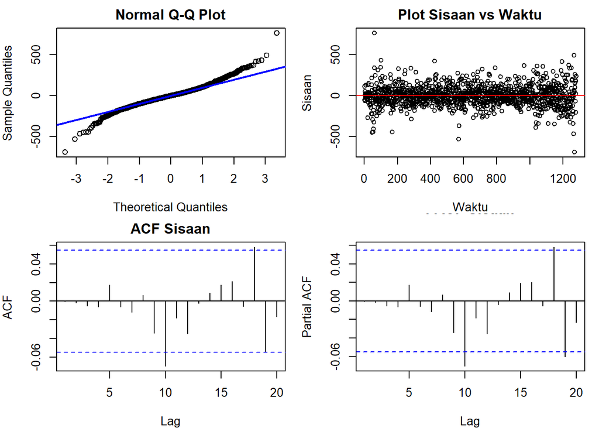

```r
sisaan <- residuals(model.20)

par(mfrow = c(2, 2), mar = c(4, 4, 2, 1))
qqnorm(sisaan, main = "Normal Q-Q Plot"); qqline(sisaan, col = "blue", lwd = 2)
plot(sisaan, type = "p", main = "Plot Sisaan vs Waktu", xlab = "Waktu", ylab = "Sisaan")
abline(h = 0, col = "red")
acf(sisaan,  lag.max = 20, main = "ACF Sisaan")
pacf(sisaan, lag.max = 20, main = "PACF Sisaan")
```

```r
par(mfrow = c(1, 1))
```

- **Q-Q plot**: bagian tengah titik-titik mengikuti garis, tetapi **ekor kiri dan kanan menyimpang** dari garis. Ada beberapa pengamatan ekstrem (sisaan sekitar -700 hingga +750). Ini mengindikasikan sisaan memiliki ekor lebih berat daripada sebaran normal.
- **Sisaan vs waktu**: sisaan berpencar di sekitar nol tanpa pola, tetapi lebar sebarannya **tidak sepenuhnya seragam**: terdapat periode dengan simpangan lebih besar dan periode yang lebih tenang.
- **ACF dan PACF sisaan**: hampir seluruh lag berada di dalam batas signifikansi, kecuali sedikit lag yang menyentuh batas (lag 10, 18, 19), yang terisolasi dan wajar terjadi secara kebetulan. Sisaan secara visual dapat dianggap **saling bebas**.

## Uji Formal

### Normalitas Sisaan

$H_0$ : sisaan menyebar normal

$H_1$ : sisaan tidak menyebar normal

Uji Kolmogorov-Smirnov dilakukan terhadap sebaran normal dengan rataan dan simpangan baku yang diduga dari sisaan itu sendiri. Argumen `mean` dan `sd` wajib diisi, sebab tanpa keduanya `ks.test(..., "pnorm")` membandingkan sisaan dengan N(0,1) yang pasti ditolak ketika skala data besar seperti harga saham.

```r
ks.test(sisaan, "pnorm", mean = mean(sisaan), sd = sd(sisaan))
```

```
##
##  Asymptotic one-sample Kolmogorov-Smirnov test
##
## data:  sisaan
## D = 0.056163, p-value = 0.0006265
## alternative hypothesis: two-sided
```

```r
tseries::jarque.bera.test(sisaan)
```

```
##
##  Jarque Bera Test
##
## data:  sisaan
## X-squared = 552.46, df = 2, p-value < 2.2e-16
```

### Kebebasan Sisaan (Tidak Ada Autokorelasi)

$H_0$ : sisaan saling bebas

$H_1$ : sisaan tidak saling bebas

```r
Box.test(sisaan, lag = 1,  type = "Ljung-Box")
```

```
##
##  Box-Ljung test
##
## data:  sisaan
## X-squared = 0.00017202, df = 1, p-value = 0.9895
```

```r
Box.test(sisaan, lag = 10, type = "Ljung-Box")
```

```
##
##  Box-Ljung test
##
## data:  sisaan
## X-squared = 8.5639, df = 10, p-value = 0.5739
```

```r
Box.test(sisaan, lag = 20, type = "Ljung-Box")
```

```
##
##  Box-Ljung test
##
## data:  sisaan
## X-squared = 20.31, df = 20, p-value = 0.4387
```

### Kehomogenan Ragam Sisaan

$H_0$ : ragam sisaan homogen

$H_1$ : ragam sisaan tidak homogen

Kehomogenan ragam diuji dengan Ljung-Box pada **sisaan kuadrat**. Jika sisaan kuadrat berautokorelasi, ragam sisaan berubah-ubah menurut waktu (efek ARCH).

```r
Box.test(sisaan^2, lag = 1,  type = "Ljung-Box")
```

```
##
##  Box-Ljung test
##
## data:  sisaan^2
## X-squared = 4.4672, df = 1, p-value = 0.03455
```

```r
Box.test(sisaan^2, lag = 10, type = "Ljung-Box")
```

```
##
##  Box-Ljung test
##
## data:  sisaan^2
## X-squared = 128.55, df = 10, p-value < 2.2e-16
```

```r
Box.test(sisaan^2, lag = 20, type = "Ljung-Box")
```

```
##
##  Box-Ljung test
##
## data:  sisaan^2
## X-squared = 155.39, df = 20, p-value < 2.2e-16
```

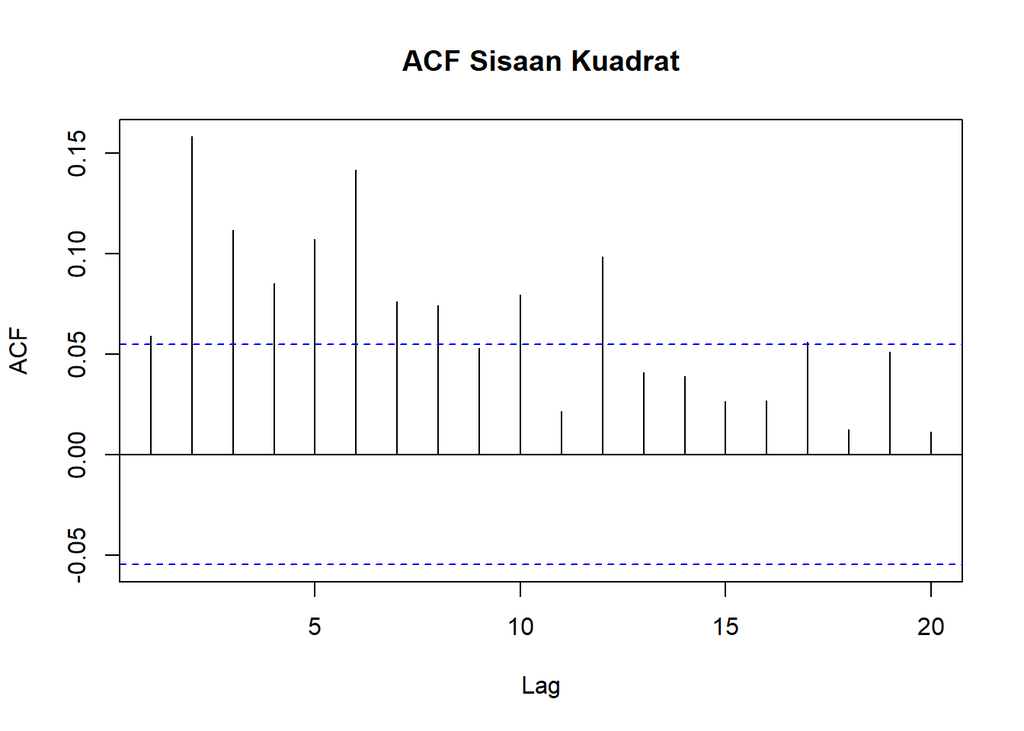

```r
acf(sisaan^2, lag.max = 20, main = "ACF Sisaan Kuadrat")
```

*P-value* pada lag 1 sebesar 0,035 dan pada lag 10 serta 20 mendekati nol (< 2,2e-16), seluruhnya lebih kecil dari 5%, sehingga **tolak $H_0$**: ragam sisaan **tidak homogen**. Terdapat efek ARCH atau *volatility clustering*: periode bergejolak cenderung diikuti periode bergejolak, dan periode tenang diikuti periode tenang. Hal ini wajar pada harga saham dan sesuai dengan pengamatan pada plot sisaan.

### Nilai Tengah Sisaan Sama dengan Nol

$H_0$ : nilai tengah sisaan sama dengan 0

$H_1$ : nilai tengah sisaan tidak sama dengan 0

```r
t.test(sisaan, mu = 0, conf.level = 0.95)
```

```
##
##  One Sample t-test
##
## data:  sisaan
## t = -0.007853, df = 1278, p-value = 0.9937
## alternative hypothesis: true mean is not equal to 0
## 95 percent confidence interval:
##  -6.722985  6.669377
## sample estimates:
##   mean of x
## -0.02680418
```

### Kesimpulan Analisis Sisaan

[output not shown]

Asumsi yang paling krusial untuk peramalan titik, yaitu **sisaan saling bebas dan bernilai tengah nol**, terpenuhi, sehingga model ARIMA(2,1,0) sudah menangkap seluruh struktur autokorelasi pada rataan data. Dua asumsi lainnya tidak terpenuhi: **tidak normal** (ekor berat) dan **ragam tidak homogen** (efek ARCH). Konsekuensinya, dugaan titik tetap layak digunakan, tetapi **selang prediksi berbasis kenormalan dan ragam konstan cenderung kurang tepat** (terlalu sempit saat pasar bergejolak dan terlalu lebar saat tenang). Pada praktik di luar cakupan praktikum ini, hal tersebut biasanya ditangani dengan model ragam bersyarat seperti ARIMA-GARCH.

# Overfitting

Overfitting dilakukan dengan menaikkan orde AR atau MA satu tingkat dari model terbaik ARIMA(2,1,0), sehingga diperoleh **ARIMA(3,1,0)** dan **ARIMA(2,1,1)**. Model hasil *overfitting* diterima hanya jika parameter tambahannya signifikan dan AIC-nya lebih kecil.

## ARIMA(3,1,0)

```r
model.30 <- Arima(train.diff, order = c(3,0,0), method = "ML")
model.30
```

```
## Series: train.diff
## ARIMA(3,0,0) with non-zero mean
##
## Coefficients:
##           ar1      ar2      ar3    mean
##       -0.1302  -0.0837  -0.0057  1.5654
## s.e.   0.0280   0.0282   0.0280  2.7982
##
## sigma^2 = 14935:  log likelihood = -7959.37
## AIC=15928.75   AICc=15928.8   BIC=15954.52
```

```r
lmtest::coeftest(model.30)
```

```
##
## z test of coefficients:
##
##             Estimate Std. Error z value  Pr(>|z|)
## ar1       -0.1302354  0.0280027 -4.6508 3.306e-06 ***
## ar2       -0.0836617  0.0281649 -2.9704  0.002974 **
## ar3       -0.0056753  0.0280307 -0.2025  0.839551
## intercept  1.5654225  2.7981779  0.5594  0.575859
## ---
## Signif. codes:  0 '***' 0.001 '**' 0.01 '*' 0.05 '.' 0.1 ' ' 1
```

## ARIMA(2,1,1)

```r
model.21 <- Arima(train.diff, order = c(2,0,1), method = "ML")
model.21
```

```
## Series: train.diff
## ARIMA(2,0,1) with non-zero mean
##
## Coefficients:
##           ar1      ar2      ma1    mean
##       -0.0646  -0.0752  -0.0656  1.5697
## s.e.   0.3576   0.0523   0.3587  2.7977
##
## sigma^2 = 14935:  log likelihood = -7959.37
## AIC=15928.74   AICc=15928.79   BIC=15954.51
```

```r
lmtest::coeftest(model.21)
```

```
##
## z test of coefficients:
##
##            Estimate Std. Error z value Pr(>|z|)
## ar1       -0.064612   0.357603 -0.1807   0.8566
## ar2       -0.075190   0.052313 -1.4373   0.1506
## ma1       -0.065578   0.358710 -0.1828   0.8549
## intercept  1.569681   2.797671  0.5611   0.5748
```

Kedua model *overfitting* tidak memperbaiki AIC dan parameter tambahannya tidak signifikan. Maka **ARIMA(2,1,0) tetap menjadi model terbaik**.

# Model Terbaik: ARIMA(2,1,0)

## Intersep (Drift) Model

```r
model.final <- Arima(train.diff, order = c(2,0,0), include.mean = FALSE, method = "ML")
model.final
```

```
## Series: train.diff
## ARIMA(2,0,0) with zero mean
##
## Coefficients:
##           ar1      ar2
##       -0.1296  -0.0827
## s.e.   0.0279   0.0279
##
## sigma^2 = 14916:  log likelihood = -7959.54
## AIC=15925.09   AICc=15925.11   BIC=15940.55
```

```r
lmtest::coeftest(model.final)
```

```
##
## z test of coefficients:
##
##      Estimate Std. Error z value  Pr(>|z|)
## ar1 -0.129559   0.027913 -4.6415 3.458e-06 ***
## ar2 -0.082746   0.027931 -2.9625  0.003051 **
## ---
## Signif. codes:  0 '***' 0.001 '**' 0.01 '*' 0.05 '.' 0.1 ' ' 1
```

```r
c(AIC.dengan.drift = AIC(model.20), AIC.tanpa.drift = AIC(model.final))
```

```
## AIC.dengan.drift  AIC.tanpa.drift
##         15926.79         15925.09
```

Model tanpa intersep memiliki AIC lebih kecil (15925.09 < 15926.79) dan seluruh parameternya signifikan, sehingga **ARIMA(2,1,0) tanpa *drift*** digunakan sebagai model akhir untuk peramalan. (Peramalan dengan *drift* tetap dibandingkan pada bagian berikutnya sebagai analisis sensitivitas.)

Model akhir dalam bentuk $w_t = Y_t - Y_{t-1}$:

$$w_t = -0.1296\,w_{t-1} -0.0828\,w_{t-2}
+ e_t$$

atau dalam bentuk harga:

$$Y_t = 0.8704\,Y_{t-1} + 0.0468\,Y_{t-2}
+ 0.0828\,Y_{t-3} + e_t$$

**Interpretasi:** koefisien AR bernilai **negatif** pada kedua lag. Perubahan harga hari ini cenderung dikoreksi sebagian pada hari-hari berikutnya: kenaikan sebesar Rp100 hari ini diikuti kecenderungan penurunan sekitar Rp13 pada hari berikutnya dan sekitar Rp8 pada hari kedua. Besarnya koefisien kecil, sehingga harga BBCA sangat mendekati *random walk* (selisih harian nyaris tidak bisa diprediksi dari selisih sebelumnya) dengan sedikit pembalikan jangka sangat pendek.

# Peramalan

Peramalan dilakukan sebanyak **h = 320** hari ke depan (sepanjang data uji). Ramalan dilakukan pada data hasil *differencing*, kemudian dikembalikan ke skala semula dengan *inverse differencing* (`diffinv`) berawal dari pengamatan terakhir data latih (Rp8.725). Selang prediksi 95% diperoleh dari model yang sama pada data asli (`order = c(2,1,0)`).

```r
# ramalan pada data differencing, lalu inverse differencing
ramalan.diff <- forecast::forecast(model.final, h = h)
hasil <- diffinv(ramalan.diff$mean, differences = 1, xi = tail(train.ts, 1))[-1]

# model ekuivalen pada data asli untuk memperoleh selang prediksi 95%
model.lvl <- Arima(train.ts, order = c(2,1,0), method = "ML")
fc.lvl    <- forecast::forecast(model.lvl, h = h, level = 95)

perbandingan <- data.frame(
  Tanggal  = bbca$Tanggal[(n.train + 1):n],
  Aktual   = as.numeric(test.ts),
  Ramalan  = round(as.numeric(hasil), 2),
  Bawah95  = round(as.numeric(fc.lvl$lower), 2),
  Atas95   = round(as.numeric(fc.lvl$upper), 2)
)
head(perbandingan, 10)
```

```
##       Tanggal Aktual Ramalan Bawah95  Atas95
## 1  2025-04-24   8475 8679.30 8439.93 8918.67
## 2  2025-04-25   8600 8666.60 8349.25 8983.95
## 3  2025-04-28   8775 8672.03 8300.82 9043.24
## 4  2025-04-29   8725 8672.38 8252.05 9092.71
## 5  2025-04-30   8825 8671.88 8207.30 9136.46
## 6  2025-05-02   8975 8671.92 8167.13 9176.71
## 7  2025-05-05   8975 8671.95 8129.94 9213.97
## 8  2025-05-06   9025 8671.95 8095.08 9248.81
## 9  2025-05-07   9075 8671.95 8062.22 9281.67
## 10 2025-05-08   8975 8671.95 8031.05 9312.84
```

```r
tail(perbandingan, 5)
```

```
##        Tanggal Aktual Ramalan Bawah95   Atas95
## 316 2026-08-14   6350 8671.95 5159.00 12184.89
## 317 2026-08-18   6300 8671.95 5153.45 12190.44
## 318 2026-08-19   6300 8671.95 5147.92 12195.97
## 319 2026-08-20   6400 8671.95 5142.39 12201.50
## 320 2026-08-21   6450 8671.95 5136.87 12207.02
```

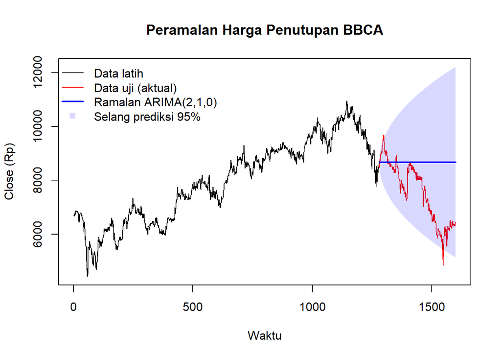

```r
ts.plot(train.ts, test.ts, col = c("black", "red"), xlab = "Waktu", ylab = "Close (Rp)",
        xlim = c(1, n), ylim = range(c(bbca$Close, fc.lvl$lower, fc.lvl$upper)),
        main = "Peramalan Harga Penutupan BBCA")
polygon(c(n.train + 1:h, rev(n.train + 1:h)),
        c(as.numeric(fc.lvl$upper), rev(as.numeric(fc.lvl$lower))),
        col = rgb(0, 0, 1, 0.15), border = NA)
lines(n.train + 1:h, hasil, col = "blue", lwd = 2)
legend("topleft", legend = c("Data latih", "Data uji (aktual)", "Ramalan ARIMA(2,1,0)", "Selang prediksi 95%"),
       col = c("black", "red", "blue", rgb(0, 0, 1, 0.15)), lty = c(1, 1, 1, NA),
       pch = c(NA, NA, NA, 15), lwd = c(1, 1, 2, NA), bty = "n")
```

Ramalan ARIMA(2,1,0) berbentuk **hampir mendatar** di sekitar Rp8.672, dan itu wajar. Karena data telah di-*differencing* sekali dan koefisien AR kecil, ramalan jangka panjang model ini pada dasarnya adalah nilai terakhir data latih (Rp8.725) yang diteruskan ke depan, dengan selang prediksi yang melebar seiring bertambahnya horizon. Pada kenyataannya harga BBCA di periode uji turun tajam hingga mendekati Rp4.850, jauh di bawah garis ramalan. Garis aktual tetap berada di dalam selang prediksi 95% pada **96,9%** hari uji, tetapi selang tersebut sangat lebar (di akhir periode ± Rp3.532).

## Akurasi Peramalan

```r
akurasi <- function(aktual, ramalan) {
  e <- as.numeric(aktual) - as.numeric(ramalan)
  c(ME = mean(e), RMSE = sqrt(mean(e^2)), MAE = mean(abs(e)),
    MAPE = mean(abs(e / as.numeric(aktual))) * 100)
}

# sensitivitas: ARIMA(2,1,0) dengan drift dan pembanding naif (nilai terakhir)
ramalan.drift <- diffinv(forecast::forecast(model.20, h = h)$mean, xi = tail(train.ts, 1))[-1]
ramalan.naif  <- rep(as.numeric(tail(train.ts, 1)), h)

round(rbind(
  "ARIMA(2,1,0) tanpa drift"  = akurasi(test.ts, hasil),
  "ARIMA(2,1,0) dengan drift" = akurasi(test.ts, ramalan.drift),
  "Naif (nilai terakhir)"     = akurasi(test.ts, ramalan.naif)
), 2)
```

```
##                                 ME    RMSE     MAE  MAPE
## ARIMA(2,1,0) tanpa drift  -1129.06 1571.01 1228.79 18.64
## ARIMA(2,1,0) dengan drift -1381.44 1846.74 1472.12 22.23
## Naif (nilai terakhir)     -1182.11 1609.56 1269.14 19.22
```

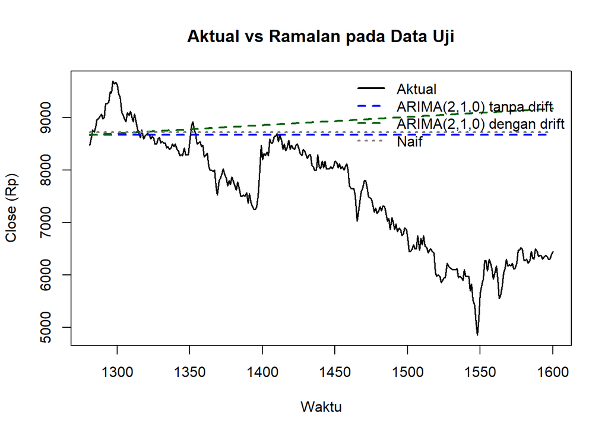

```r
plot(test.ts, type = "l", col = "black", lwd = 1.5, xlab = "Waktu", ylab = "Close (Rp)",
     ylim = range(test.ts, hasil, ramalan.drift), main = "Aktual vs Ramalan pada Data Uji")
lines(n.train + 1:h, hasil,         col = "blue",      lty = 2, lwd = 2)
lines(n.train + 1:h, ramalan.drift, col = "darkgreen", lty = 2, lwd = 2)
lines(n.train + 1:h, ramalan.naif,  col = "gray50",    lty = 3, lwd = 2)
legend("topright", legend = c("Aktual", "ARIMA(2,1,0) tanpa drift", "ARIMA(2,1,0) dengan drift", "Naif"),
       col = c("black", "blue", "darkgreen", "gray50"), lty = c(1, 2, 2, 3), lwd = 2, bty = "n")
```

# Kesimpulan